# **Lab 1: Introduction to remote sensing**

Hans Ole Ørka, 3. September 2025

# Install software

- Download and install QGIS from https://qgis.org/download/. (3.44 LTR version)
- Download and install R from https://cran.r-project.org/
- Download and install RStudio from https://posit.co/products/open-source/rstudio.

# *Part 1: Explore Image Data in QGIS*

**Goal:** Understand spatial, spectral, and radiometric resolution and refresh QGIS skills.

**Data:** The required data for this lab is available accessed via this link: https://bit.ly/3sZzfTm. The dataset includes five different optical images and a GeoPackage.

## Task 1: Explore remotely sensed image data in QGIS

Download the optical data sources provided and open them in QGIS. Describe the data with respect to:

- Spatial resolution
- Spectral resolution
- Radiometric resolution
- Minimum detectable object in meters

**Question:** What is the relationship between pixel size and detectable object size?

| File name | Spatial | Spectral | Radiometric | Minimum detectable object (meter) |
| --- | --- | --- | --- | --- |
| cir |  |  |  |  |
| rgb |  |  |  |  |
| planet |  |  |  |  |
| sentinel2A |  |  |  |  |
| sentinel2B |  |  |  |  |

## Task 2: Collect references data by digitization

We maye skip due to time - use the geopackage named *lab1_my.gpkg*

Digitize land cover types (Forest, Cropland, Grassland, Settlements, Water, Wetland, Other land) using the datasets with the highest spatial resolution. You should create polygons e.g.

[figure not shown]

Save as [geopackage](https://www.geopackage.org/).

# *Part 2: Remote sensing analysis and spatial analysis in R*

**Goal:** Carry out your first remote sensing analysis and get familiar with R and RStudio. The analysis involves classifying land cover types using the digitized reference data provided in Part 1, while learning basic R syntax and how to work with spatial data.

**Data:** You should also incorporate the digitized land cover type polygons from part 1 of this exercise (refered to as ’ *lab1_my.gpkg*’ below). The attribute representing the land cover types - Forest, Cropland, Grassland, Settlements, Water, Wetland, and Other land - is named *Type* in the example provide below. Your name of this attribute and the names representing the classes may differ.

## Task 1: Spatial data in R

First read in vector data to be used.

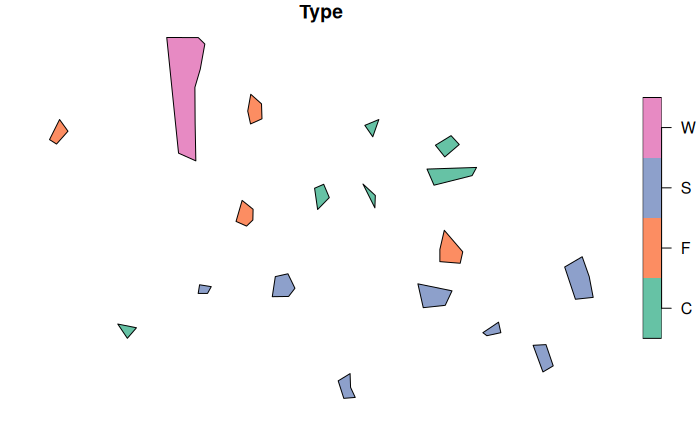

```r
library(sf)
g <- read_sf("data/lab1_my.gpkg") #Read your digitized polygons
g$ID <- c(1:nrow(g)) #Create a unique ID for each polygon (record/row)
plot(g["Type"]) #Plot the attribute (Column) containing the land cover types.
```

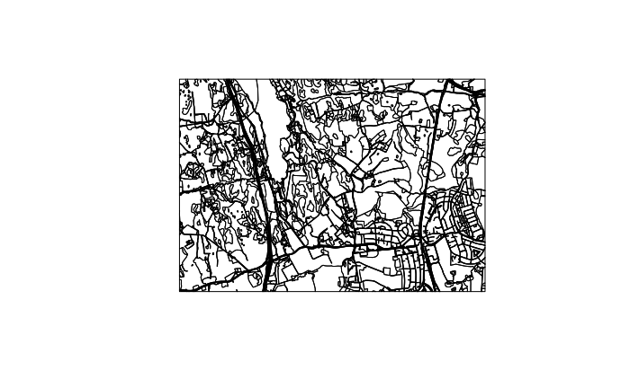

```r
ar5 <- read_sf("data/lab1.gpkg","ar5") #Read the Norwegian land cover dataset AR5 (Arealressurskart 1:5000)
plot(st_geometry(ar5)) #Plot only the geometry (outline) of this
```

### Making overlay analysis i R - intersection

R can be used to do spatial analysis e.g. overlay anlysis such as union ( *st_union* ), intersection ( *st_intersection*) and more.

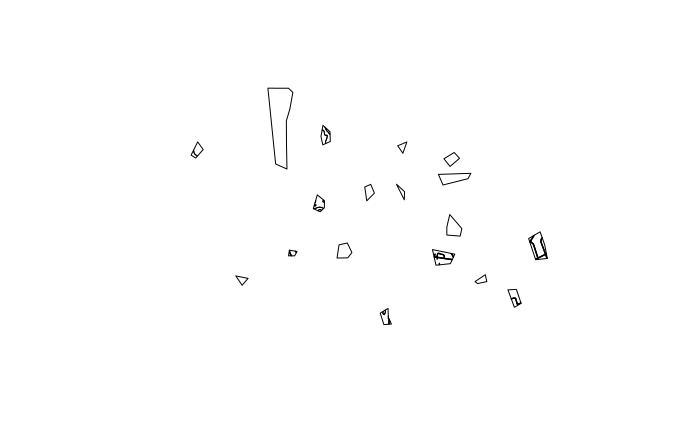

```r
g <- st_transform(g,st_crs(ar5)) # project coordinat system of your polygons to the same system as ar5 - land cover dataset.
int <- st_intersection(ar5,g) #If error see below
plot(st_geometry(int))
```

### Geting raster data (optical imagery) into R

There are several packages that allows for getting raster data into R. The most common is the **raster** package that now is gradully replaced by the **terra** package. In addition there is a package called **stars** dealing with spatiotemporal arrays.

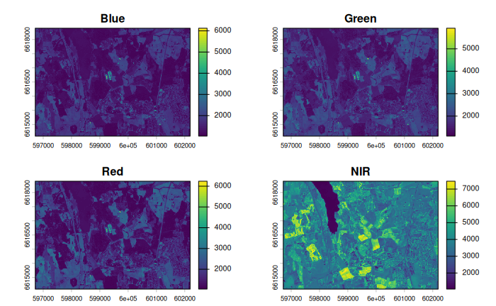

```r
library(terra) #Load the terra package if you not install you need to install it (install.packages())
# Sentinel 2
s2 <- rast("data/sentinel2A.tif")
plot(s2)
```

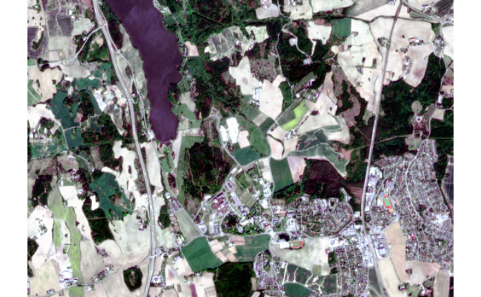

```r
plotRGB(s2, r=3, g=2, b=1, stretch="hist")
```

We like to extract pixels from our training areas and combine them with the interpreted information i.e. your polygons. To extract pixel values for the digitized polygons we used the *extract* function of the **terra** package and combine the two data sources.

```r
#If you have a older version you need to convert the sf object into a terra vector data
#g <- vect(g)
e <- extract(s2,g) # Extract information
head(e)
```

|  | ID | Blue | Green | Red | NIR |
| --- | --- | --- | --- | --- | --- |
| 1 | 1 | 1142 | 1334 | 1174 | 3896 |
| 2 | 1 | 1132 | 1292 | 1144 | 3534 |
| 3 | 1 | 1136 | 1275 | 1135 | 3762 |
| 4 | 1 | 1153 | 1285 | 1123 | 3666 |
| 5 | 1 | 1147 | 1323 | 1168 | 3644 |
| 6 | 1 | 1153 | 1322 | 1152 | 3814 |

```r
g2 <- merge(g,e,by="ID") #Merge the two tables into one using ID
g2$Type <- as.factor(g2$Type) # Convert to factor i.e. categorical variable in R
head(g2)
```

```
Simple feature collection with 6 features and 6 fields
Geometry type: POLYGON
Dimension:     XY
Bounding box:  xmin: 597376.9 ymin: 6616905 xmax: 597521.3 ymax: 6617097
Projected CRS: WGS 84 / UTM zone 32N
  ID Type Blue Green  Red  NIR                       geometry
1  1    F 1142  1334 1174 3896 POLYGON ((597455.5 6617097,...
2  1    F 1132  1292 1144 3534 POLYGON ((597455.5 6617097,...
3  1    F 1136  1275 1135 3762 POLYGON ((597455.5 6617097,...
4  1    F 1153  1285 1123 3666 POLYGON ((597455.5 6617097,...
5  1    F 1147  1323 1168 3644 POLYGON ((597455.5 6617097,...
6  1    F 1153  1322 1152 3814 POLYGON ((597455.5 6617097,...
```

## Task 2: Create a classification

We aim to create a classification model using the data extracted from our training polygons. In this example, we employ the randomForest algorithm. Random forests are an easy-to-use machine learning algorithm that usually preforms well.

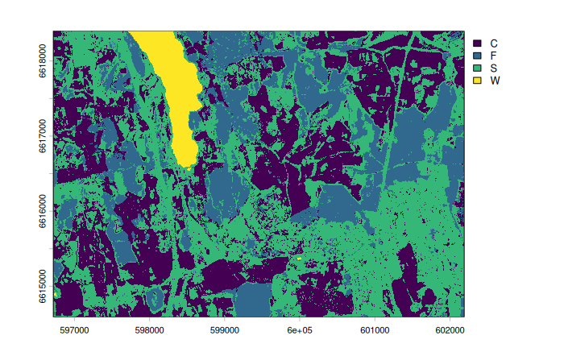

```r
library(randomForest)
rf1 <- randomForest(Type~Blue+Green+Red+NIR,data=g2)
pred <- predict(s2,rf1)
plot(pred)
```

```r
#writeRaster(pred,"data/lab1/classification.tif") # Save to disk (# means that it is commented out and will not be run, remove # to save on disk)
```

We could also use other classification algorithms, such as linear discriminant analysis (LDA).

```r
dat <- st_drop_geometry(g2[,-1])
head(dat)
```

|  | Type | Blue | Green | Red | NIR |
| --- | --- | --- | --- | --- | --- |
| 1 | F | 1142 | 1334 | 1174 | 3896 |
| 2 | F | 1132 | 1292 | 1144 | 3534 |
| 3 | F | 1136 | 1275 | 1135 | 3762 |
| 4 | F | 1153 | 1285 | 1123 | 3666 |
| 5 | F | 1147 | 1323 | 1168 | 3644 |
| 6 | F | 1153 | 1322 | 1152 | 3814 |

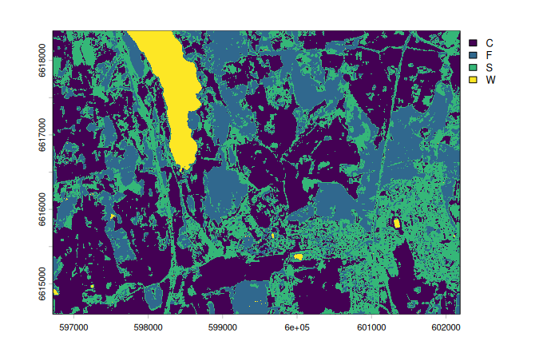

```r
library(MASS)
lda1 <- lda(Type~.,data=dat)
pd <- function(lda1,..){predict(lda1,..)$class}
pred <- predict(s2,lda1,fun=pd)
plot(pred)
```

```r
#writeRaster(pred,"data/lab1/classification_planet2.tif")
```

> *NOTE:* Any differences? Where are the errors. Can you improve?

## Task 3: Check accuracy

Accuracy is evaluated using a so-called error matrix that summarizes the number of observations according to the actual class and predicted class. The diagonal of the matrix shows the correctly classified observations. A useful reference for the error matrix is: Congalton, R. G. (1991). A review of assessing the accuracy of classifications of remotely sensed data. Remote Sensing of Environment, 37(1), 35–46. https://doi.org/10.1016/0034-4257(91)90048-B

```r
library(dplyr)
pkt <- st_sample(ar5,size=1000) # Random sample of points within the ar5 dataset
pkt <- st_intersection(ar5 %>% dplyr::select(IPCC,geom),pkt) #Intersection with ar5 i.e. extract teh IPCC - value
head(pkt)
```

```
Simple feature collection with 6 features and 1 field
Geometry type: POINT
Dimension:     XY
Bounding box:  xmin: 597543.3 ymin: 6614858 xmax: 601454.1 ymax: 6618352
Projected CRS: WGS 84 / UTM zone 32N
```

| IPCC | geom |
| --- | --- |
| Cropland |  |
| Cropland |  |
| Forest |  |
| Settlements |  |
| Other |  |
| Cropland |  |

```r
e <- extract(pred,vect(pkt)) #Extract predicted value from the pixel at the point location
pkt <- cbind(pkt,e[,-c(1)]) #Combine
names(pkt)[2] <- "Predicted"
head(pkt)
```

```
Simple feature collection with 6 features and 2 fields
Geometry type: POINT
Dimension:     XY
Bounding box:  xmin: 597543.3 ymin: 6614858 xmax: 601454.1 ymax: 6618352
Projected CRS: WGS 84 / UTM zone 32N
         IPCC Predicted                     geom
1    Cropland         S POINT (598605.1 6614858)
2    Cropland         C POINT (601454.1 6618027)
3      Forest         F POINT (600467.6 6616126)
4 Settlements         C POINT (600159.4 6616745)
5       Other         S POINT (597543.3 6617750)
6    Cropland         C POINT (600579.8 6618352)
```

```r
pkt$Reference <- substr(pkt$IPCC,1,1)
pkt$Predicted <- factor(pkt$Predicted,labels=unique(pkt$Reference),levels=unique(pkt$Reference))
pkt$Reference <- factor(pkt$Reference,labels=unique(pkt$Reference),levels=unique(pkt$Reference))
#Create errormatrix
em <- xtabs(~Predicted+Reference,data=pkt,addNA=T)
em
```

```
         Reference
Predicted   C   F   S   O   W   G
        C 342  19  50  23   0   8
        F   3 179  24   5   4   0
        S  71  81 132  15   2   4
        O   0   0   0   0   0   0
        W   0   1   1   0  36   0
        G   0   0   0   0   0   0
```

```r
sum(diag(em)) / sum(em)
```

```
[1] 0.689
```